# Data612 - Project3

Abdelmalek Hajjam

6/22/2020

## Introduction

The goal of this assignment is to implement a matrix factorization method—such as singular value decomposition (SVD) or Alternating Least Squares (ALS)—in the context of a recommender system.

Matrix Factorization or matrix decomposition is factorization of that matrix into three matrices. The product of these matrices will produce the original matrix. Matrix Factorization is one of the most popular algorithms to solve co-clustering problem.

Singular Value Decomposition (SVD) is a matrix factorization technique to reduce the dimension of impute data.The idea is to find the direction of maximum variances and retain only those who can considerably explain variation in data. While SVD can achieve a very good result on non-sparse data, in real life SVD doesn’t work so well on data - as real-life data is significantly sparse. SVD function in recommenderLab package uses column-mean as default method for missing values impute. This usually works OK, but results are usually biased.well.

## Data loading

```r
library(recommenderlab)
library(kableExtra)
library(ggplot2)
library(dplyr)
library(tidyr)
```

```r
# reading Data
data(MovieLense)
movieMatrix<-MovieLense

data.frame(as(MovieLense, "matrix")[1:5, 1:5]) %>% kable(col.names = colnames(MovieLense)[1:5]) %>% kable_styling(full_width = T)
```

| Toy Story (1995) | GoldenEye (1995) | Four Rooms (1995) | Get Shorty (1995) | Copycat (1995) |
| --- | --- | --- | --- | --- |
| 5 | 3 | 4 | 3 | 3 |
| 4 | NA | NA | NA | NA |
| NA | NA | NA | NA | NA |
| NA | NA | NA | NA | NA |
| 4 | 3 | NA | NA | NA |

## Data Exploration

Let’s look at the distribution of rating through visualization.

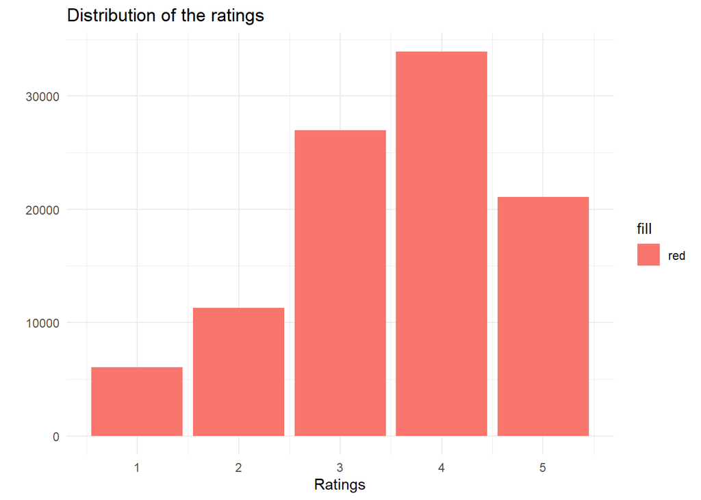

```r
# distribution of ratings
MovieLense@data %>%
  as.vector() %>%
  as_tibble() %>%
  filter_all(any_vars(. != 0)) %>%
  ggplot(aes(value, fill='red')) +
  geom_bar() +
  labs(title = "Distribution of the ratings", y = "", x = "Ratings") +
  theme_minimal()
```

Looks like 4 was the most popular rating value.